# hw13

**Q1**

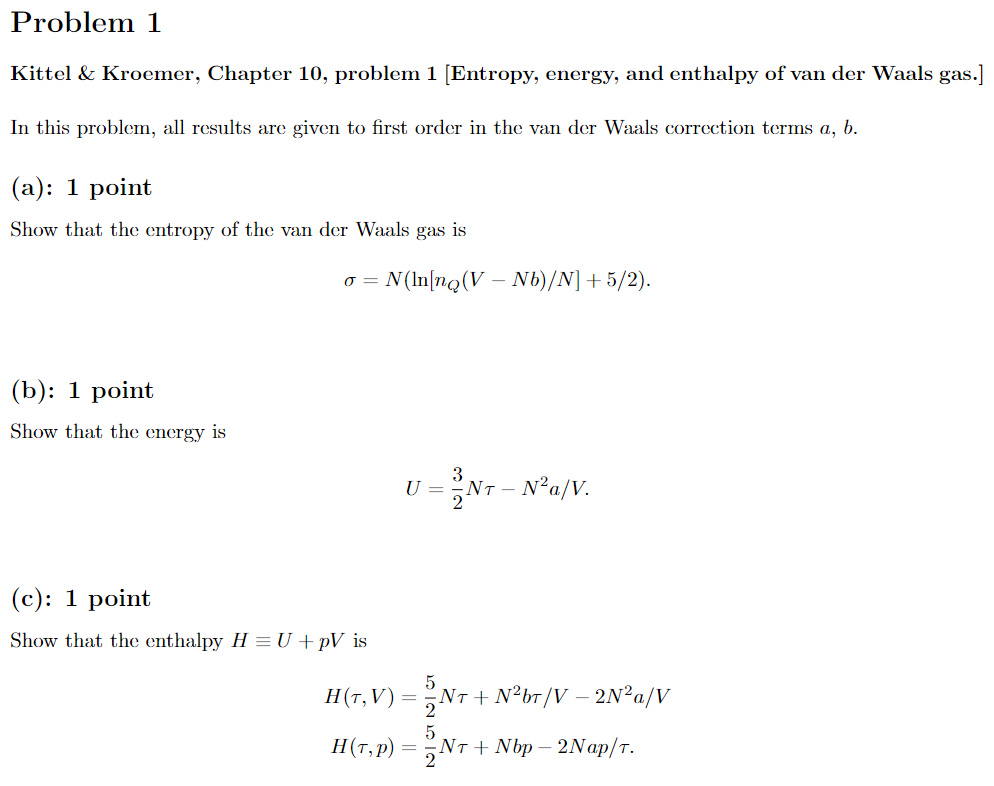

We're given the van der Waals equation of state in (33) and the free energy $F$ in (38).

Relevant equations: $$ U = F + \sigma \tau \\ \sigma = - \frac{\partial F}{\partial \tau}_{V,N} \\ p = - \frac{\partial F}{\partial V}_{\tau,N} $$

We're also given pressure in (39)

$$ p = \frac{N \tau}{V-Nb} - \frac{N^2 a}{V^2} $$

(a)

$$ F_{\text{vdW}} = -N\tau \left[\ln\left( \frac{n_Q (V - Nb)}{N}\right) + 1\right] - \frac{N^2 a}{V} \\ $$

Note that $n_Q$ depends on $\tau$, so let's use $n_Q'$ independent of $\tau$

$$ F_{\text{vdW}} =-N\tau \left[\ln\left( \tau^{3/2}\frac{n_Q' (V - Nb)}{N}\right) + 1\right] - \frac{N^2 a}{V} \\ \sigma = -\frac{\partial F}{\partial \tau} = N + N\frac{\partial }{\partial \tau} \tau \ln\left( \tau^{3/2}\frac{n_Q' (V - Nb)}{N}\right) \\ = N + N\frac{\partial }{\partial \tau} \left[\tau \ln\left( \tau^{3/2}\right) + \tau \ln \left(\frac{n_Q' (V - Nb)}{N}\right) \right] \\ = N + N\ln(\tau^{3/2}) + \frac{3}{2} + N\ln \left(\frac{n_Q' (V - Nb)}{N}\right) \\ = N + N\ln \left(\frac{n_Q (V - Nb)}{N} \right) + N\times 3/2 \\ = N \left( \ln \left[\frac{n_Q (V-Nb)}{N} \right] + 5/2 \right) $$

(b)

$$ U = F + \sigma \tau = N\tau \left[\ln\left[ \frac{n_Q(V-Nb)}{N}\right] +\frac{5}{2} - \ln\left[ \frac{n_Q(V-Nb)}{N}\right] - 1\right] - \frac{N^2 a}{V} \\ = \frac{3}{2} N\tau - N^2 a/V $$

(c) From $p$ above

$$ p = \frac{N\tau}{V-Nb}-\frac{N^2a}{V^2} \\ H(\tau, p, V) = \frac{3}{2} N \tau - \frac{N^2 a}{V} + pV %\frac{N\tau V}{V-Nb} - \frac{N^2 a}{V} $$ How do we get $N\tau$ out of $pV$? It's in the equation of state...

```python
import sympy as sp
p, N, V, a, b, tau = sp.symbols('p N V a b tau')

eos = (p+N**2*a/V**2)*(V-N*b)
eos.expand()
```

$\displaystyle - \frac{N^{3} a b}{V^{2}} + \frac{N^{2} a}{V} - N b p + V p$

Since we know the result we're going for, we can add in $N\tau$ and subtract out the above from $H$

To finish, we just have to check some equalities: $$ Nbp - \frac{N^3 ab}{V^2} = \frac{N^2 b\tau}{V} \\ - \frac{2N^2 a}{V}- \frac{N^3 ab}{V^2} = \frac{-2Nap}{\tau} $$

For both of these, plugging in our formula for $p$ and simplifying will yield our equation of state

proving the equality.

**Q2**

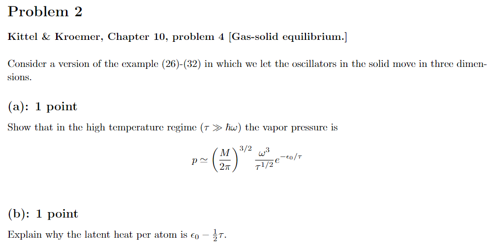

(a) The only complexity of this problem compared to the example is finding $Z = \sum_n e^{\frac{-n\hbar \omega + \epsilon_0}{\tau}}$, only with a new $n$

$$ Z = \sum_{n_x} \sum_{n_y} \sum_{n_z} e^{\frac{-\sqrt{n_x^2+n_y^2+n_z^2}\hbar \omega + \epsilon_0}{\tau}} \\ = \frac{1}{8} \int_0^\infty 4 \pi n^2 e^{\frac{-n\hbar \omega + \epsilon_0}{\tau}} dn \\ = \frac{\pi e^{\epsilon_0/\tau}}{2} \left[\frac{2\tau^3}{\hbar^3 \omega^3 } \right] = \pi e^{\frac{\epsilon_0}{\tau}} \left(\frac{\tau}{\hbar \omega}\right)^3 $$

We are trying to find the pressure when the solid and gas are in equilibrium

$$ \lambda_g = \lambda_s $$ As in (10.30), we'll use the ideal gas approximation for $\lambda_g$

$$ \lambda_g = \frac{n}{n_Q} = \frac{p}{\tau n_Q} = \frac{p}{\tau} \left(\frac{2\pi \hbar^2}{M\tau}\right)^{3/2} $$

For $\lambda_s$, we need to assume a small solid volume and apply (10.28)

$$ \mu_s = F_s + pv_s \simeq F_s = -\ln Z \\ \lambda_s \equiv e^{\mu_s/\tau} = \frac{1}{Z} = \frac{e^{-\epsilon_0/\tau}}{\pi} \left(\frac{\hbar \omega}{\tau}\right)^3 $$ This gives our pressure as $$ \lambda_g = \lambda_s \\ \frac{p}{\tau} \left(\frac{2\pi \hbar^2}{M\tau}\right)^{3/2} = \frac{e^{-\epsilon_0/\tau}}{\pi} \left(\frac{\hbar \omega}{\tau}\right)^3 \\ p \simeq \left(\frac{M}{2\pi} \right)^{3/2} \frac{\omega^3}{\tau^{1/2}}e^{-\epsilon_0/\tau} $$

(b) Using (10.18) we have

$$ L = \tau^2 \frac{d}{d\tau} \ln p = \tau^2 \frac{d}{d\tau} \left[ \ln \left( \frac{e^{-\epsilon_0/\tau}}{\tau^{1/2}}\right) + \left(\ln \left(\frac{M}{2\pi} \right)^{3/2} {\omega^3}\right)\right] \\ = \frac{2\epsilon_0 - \tau}{2} = \epsilon_0 - \frac{1}{2} \tau $$

**Q3**

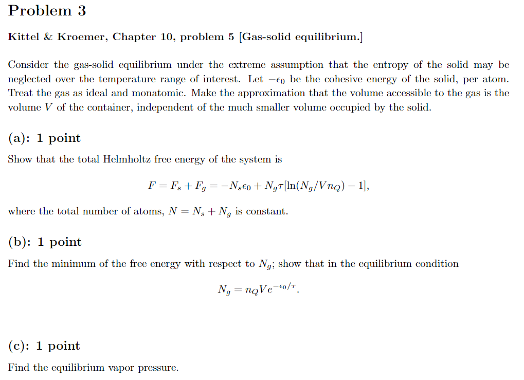

**Q4**

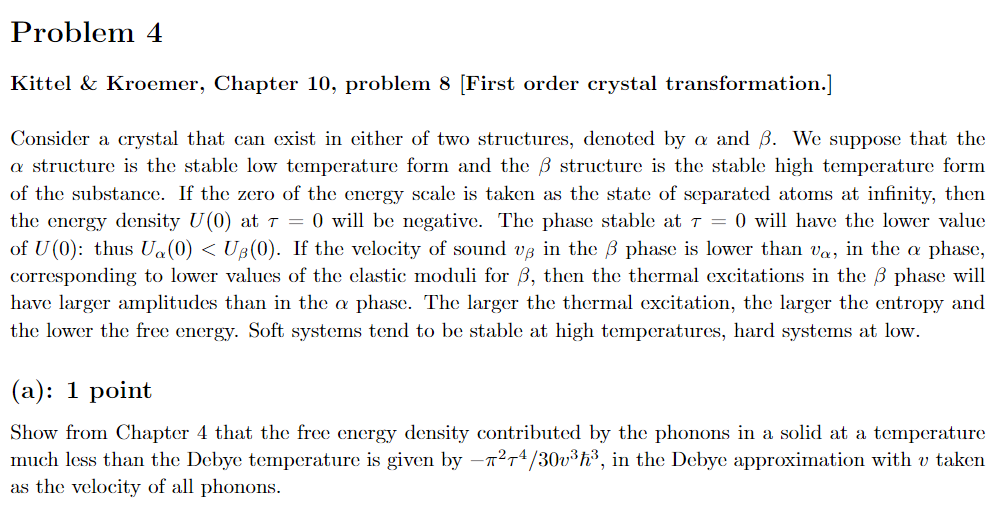

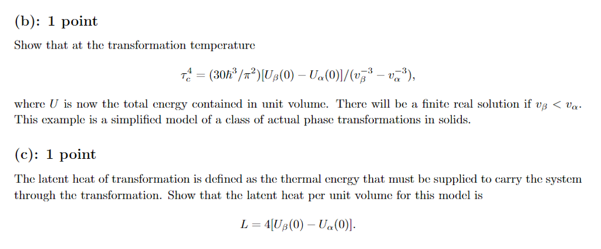

Rather than recalculating the phonon energy at low temperatures, we'll use our previous result

$$ \begin{align} &U(\tau) \simeq \frac{3\pi^4 N \tau^4}{5(k_B \theta)^3} \tag{4.46} \\ &C_V = \frac{12 \pi^4 N}{5} \left( \frac{\tau}{k_B \theta}\right)^3 \tag{4.47} \\ \end{align} $$ The free energy density is $$ \begin{align*} &F \equiv U-\tau \sigma \tag{3.35} \\ &f = \frac{F}{V} = \frac{U}{V} -\tau \frac{\sigma}{V} \\ \end{align*} $$ leaving $\sigma$ as the last value to find. We actaully have a formula for entropy from heat capacity

$$ % C_V \equiv \tau\left( \frac{\partial \sigma}{\partial \tau}\right)_V \tag{6.35} \\ \begin{align} \sigma(\tau) - \sigma(0) = \int_0^\tau \frac{C_V(\tau)}{\tau} d\tau \tag{6.39} \end{align} $$ $$ \begin{align*} \sigma(\tau) =\frac{12 \pi^4 N}{5 (k_B \theta)^3} \int_0^\tau \tau^2 d\tau = \frac{4 \pi^4 N \tau^3}{5(k_B \theta)^3} \\ \end{align*} \\ f = \frac{3\pi^4 N \tau^4}{5V(k_B \theta)^3} - \frac{4 \pi^4 N \tau^4}{5V(k_B \theta)^3} \\ $$ Now to clean things up $$ \theta = \frac{\hbar v}{k_B} \left(6\pi^2 n \right)^{1/3} \\ f = -\frac{n\pi^4 \tau^4}{5(6\pi^2 n\hbar^3 v^3)} = -\frac{\pi^2 \tau^4}{30 v^3 \hbar^3} $$

(b) Since $\alpha$ is stable at low temperature, we know $U_\alpha(0)<U_\beta(0)$, and $U_\beta(0)-U_\alpha(0)$ is positive. We know that $\tau_c^4$ must be positive, so $v_\beta$ must be less than $v_\alpha$.

The only energies here are the ground state energy $U(0)$ and phonon energy $f$, so the transition occurs when

$$ U_\alpha(0) + f_\alpha(\tau) = U_\beta(0) + f_\beta(\tau) \\ $$

These are equal at $\tau=\tau_c$, so we know a solution exists, and exists only when $v_\beta < v_\alpha$

(c) Since we have phonon entropy and $\tau_c$, we need only find $\Delta \sigma$

$$ L = \tau\Delta \sigma = \sigma_\beta(\tau_c) - \sigma_\alpha(\tau_c) \\ = \left[\frac{2 \pi^2 \tau_c^4}{15 \hbar^3} \left(v_\beta^{-3}-v_\alpha^{-3}\right) \right] \\ = \frac{2\pi^2}{15\hbar^3} \left[\frac{30\hbar^3}{\pi^2} \frac{U_\beta(0)-U_\alpha(0)}{v_\beta^{-3}-v_\alpha^{-3}}\left(v_\beta^{-3}-v_\alpha^{-3}\right)\right] \\= 4\left[ U_\beta(0) - U_\alpha(0)\right] $$